# TMBによる最尤推定

Tokyo.R 115

伊東宏樹

2024-10-19

## 自己紹介

- 氏名: 伊東宏樹
- 3月まで森林総合研究所勤務
- 4月から個人事業主（[伊東生態統計研究室](https://ito4303.sakura.ne.jp/)）
- データ解析、執筆・翻訳、研修講師などお引き受けいたします。
- 出版物: 『[BUGSで学ぶ階層モデリング入門](https://www.kyoritsu-pub.co.jp/book/b10003729.html)』『[生態学のための階層モデリング](https://www.kyoritsu-pub.co.jp/book/b10003301.html)』（以上共訳）など

## Kanazawa.R #2

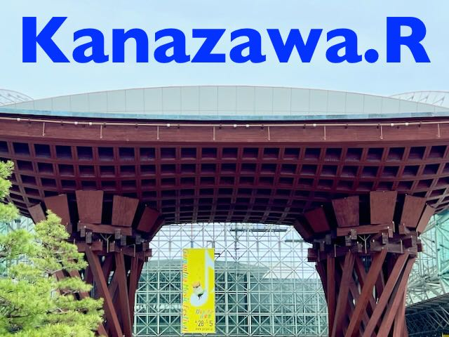

- 石川県金沢市でのR勉強会
- 第2回を11月23日開催（現地+オンライン）
- 詳細はconnpassのイベントページ(https://kanazawar.connpass.com/event/334335/)にて

## TMB

- Rパッケージ (https://cran.r-project.org/package=TMB)
  - 公式ページ: https://github.com/kaskr/adcomp/wiki
  - ドキュメント: https://kaskr.github.io/adcomp/_book/Introduction.html
- Template Model Builder: A General Random Effect Tool Inspired by ‘ADMB’
- C++のテンプレートを使って（変量効果のある）モデルの最尤推定をおこなう。

## 例

## データ

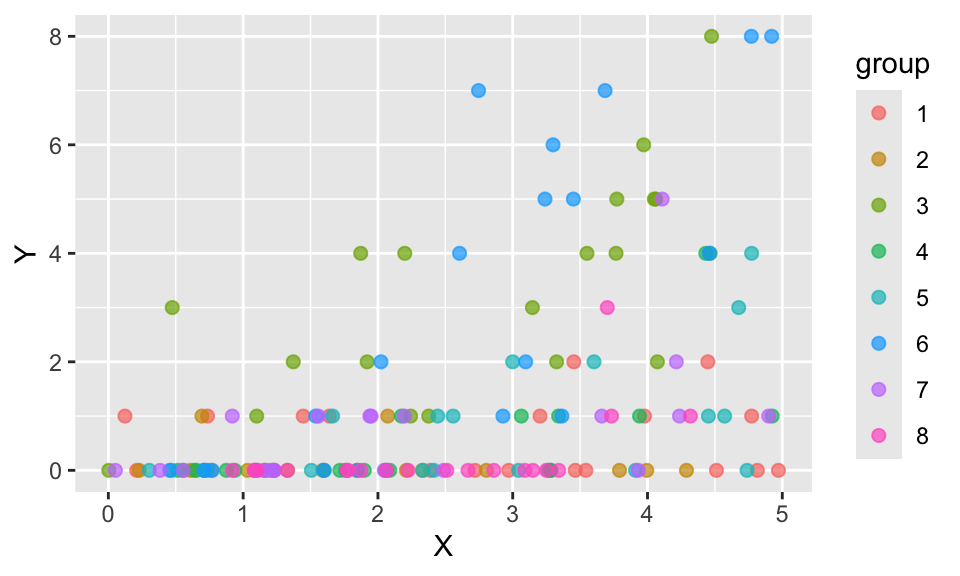

## モデル

```
poismix.cpp
```

```cpp
#include <TMB.hpp>

template<class Type>
Type objective_function<Type>::operator() ()
{
  DATA_VECTOR(Y);            // Objective variable
  DATA_VECTOR(X);            // Explanatory variable
  DATA_IVECTOR(G);           // Group index
  PARAMETER(alpha);          // Intercept
  PARAMETER(beta);           // Slope
  PARAMETER_VECTOR(epsilon); // Random effect
  PARAMETER(log_sigma);      // log SD of random effect
  Type nll = 0;              // negative log likelihood

  nll += -sum(dnorm(epsilon, Type(0.0), exp(log_sigma), true));
  for (int i = 0; i < Y.size(); i++) {
    Type lambda = exp(alpha + beta * X(i) + epsilon(G(i)));
    nll += -dpois(Y(i), lambda, true);
  }
  return nll;
}
```

## 実行

コンパイル(`compile`)→ロード(`dyn.load`)→微分関数を作成(`MakeADFun`, `random`引数に変量効果)→最適化(`nlminb`)

```r
model_name <- "poismix"
file.path("models", paste(model_name, "cpp", sep = ".")) |>
  compile()
file.path("models", dynlib(model_name)) |>
  dyn.load()
data <- list(Y = Y, X = X, G = group - 1)
parameters <- list(alpha = 0, beta = 1,
                   epsilon = rep(0, N_group), log_sigma = 0)
obj <- MakeADFun(data, parameters, DLL = model_name,
                 random = "epsilon")
opt <- nlminb(obj$par, obj$fn, obj$gr)
```

## 結果

```r
print(opt)
```

```
$par
     alpha       beta  log_sigma
-1.9741825  0.5644704 -0.1077009

$objective
[1] 182.9479

$convergence
[1] 0

$iterations
[1] 14

$evaluations
function gradient
      19       15

$message
[1] "relative convergence (4)"
```

## glmmTMB

- 内部でTMBを利用
- glmmの書式でモデル式を書ける（C++を知らなくても大丈夫）

```r
library(glmmTMB)
fit <- glmmTMB(Y ~ X + (1|group), data = df, family = poisson())
```

## 結果

```r
summary(fit)
```

```
 Family: poisson  ( log )
Formula:          Y ~ X + (1 | group)
Data: df

     AIC      BIC   logLik deviance df.resid
   371.9    381.1   -182.9    365.9      157

Random effects:

Conditional model:
 Groups Name        Variance Std.Dev.
 group  (Intercept) 0.8062   0.8979
Number of obs: 160, groups:  group, 8

Conditional model:
            Estimate Std. Error z value Pr(>|z|)
(Intercept) -1.97418    0.40252  -4.905 9.36e-07 ***
X            0.56447    0.06469   8.726  < 2e-16 ***
---
Signif. codes:  0 '***' 0.001 '**' 0.01 '*' 0.05 '.' 0.1 ' ' 1
```

## tmbstan

- TMBのオブジェクトを利用して、StanでMCMCによる推定
- 局所最適を回避できる

```r
library(tmbstan)
stanfit <- tmbstan(obj)
```

## 結果

```r
print(stanfit, pars = c("alpha", "beta", "log_sigma"))
```

```
Inference for Stan model: poismix.
4 chains, each with iter=2000; warmup=1000; thin=1;
post-warmup draws per chain=1000, total post-warmup draws=4000.

           mean se_mean   sd  2.5%   25%   50%   75% 97.5% n_eff Rhat
alpha     -1.98    0.02 0.46 -2.92 -2.28 -1.96 -1.67 -1.12   888    1
beta       0.57    0.00 0.06  0.44  0.52  0.57  0.61  0.70  1989    1
log_sigma  0.03    0.01 0.32 -0.53 -0.19  0.01  0.23  0.72  1718    1

Samples were drawn using NUTS(diag_e) at Fri Oct 18 13:11:48 2024.
For each parameter, n_eff is a crude measure of effective sample size,
and Rhat is the potential scale reduction factor on split chains (at
convergence, Rhat=1).
```